# IE48B : Time Series Analysis Project Report

## Group 4

- Ahmet Buğra Taksuk
- Hakkı Serdar Yıldız
- Dorukhan Kılınç

## 1 ) Introduction

- In this project, the main task is to develop an approach for the classification of imbalance sign for Turkish electricity market from January 8th, 2022 to 22 January 2022. Every day, the predictions consist of the prediction of the system imbalance of the next 24 hours of the next day using the data available, i.e. data until the day before (included).
- In addition to the past net electricty production data, upRegulationZeroCoded, upRegulationOneCoded,upRegulationTwoCoded, downRegulationZeroCoded, downRegulationOneCoded, downRegulationTwoCoded, upRegulationDelivered, downRegulationDelivered columns are available for external variables.
- Before moving into our summary of appraoch, we can shortly see the descriptive analytics to understand the data behaviour and understand our approach.

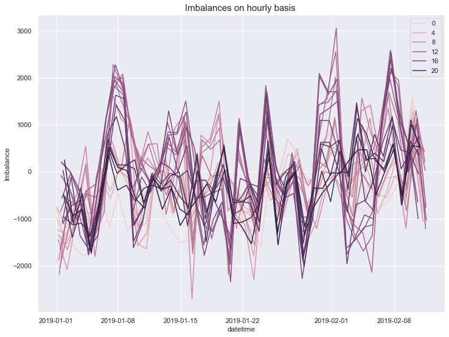

```python
sns.set(rc={'figure.figsize':(12,9)})
sns.lineplot(x = df[:1000].index, y = "net",  data = df[:1000] ,hue = 'hour')
plt.ylabel("Imbalance")
plt.title("Imbalances on hourly basis ", size = 15)
plt.legend()
plt.show()
```

- It can be seen from plot above that the imbalance values for each hour behaves differently, i.e. it is reasonable to build different models for each hour to avoid any unnecesessary generalization.

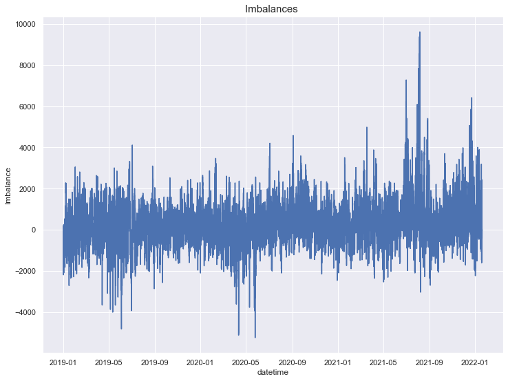

```python
sns.set(rc={'figure.figsize':(12,9)})
sns.lineplot(x = df.index, y = "net",  data = df )
plt.ylabel("Imbalance")
plt.title("Imbalances ", size = 15)
plt.show()
```

- To check whether we have a stationary data in terms of trends or seasonality terms are always useful. As far as we can see, there is not a clear trend term. For the seasonality cooncerns, since we have a hourly based dataframes, we are going to include the daily seasonality to our model.

## 2 ) Related Literature

- Increasing share of renewable energy sources (i.e. wind, solar, hydropower, geothermal) that are harder to forecast is major problem in terms of the foreseeability. Therefore, trading in the Day-Ahead Market is necessary.
- A player on demand side agrees on purchasing amount of dt for an hour t (similarly producer agrees on producing amount pt). Due to the stochasticity mentioned earlier, actual demand/production may not be consistent with the demand/production forecast. In other words, the demand/production can be larger or smaller in real life. This is so called “imbalance” problem in the system. If actual demand happens to be larger/smaller for a player on the demand side, it should purchase/sell electricity during the day (i.e. if actual demand happened to be smaller than agreed, excess demand should be sold), this is done in intra-day market (IDM) on an hourly basis.The operations are the same as day-ahead market. If a player on demand side has excess demand, it places a sell order in the market as an amount, price pair for the particular hour. If the same player is short in demand, it places an ask order as an amount, price pair for the particular hour. Operations are done in a similar way for the producer side. If a player on supply side has excess production, it places a sell order in the market as an amount, price pair for the particular hour. If the same player is short in production, it places an ask order as an amount, price pair for the particular hour
- System Direction information is the target and target assignment is performed based on the net value as

"if net>=50 then System Direction='Positive" "if net<=-50 then System Direction='Negative'" "otherwise System Direction='Neutral'"

- Up Regulation Instructions : the aggregate volume of the transactions regarding the energy deficit
- Down Regulation Instructions : the aggregate volume of the transactions regarding the energy surplus
- The main reason of the interest in the sign of the system imbalance is due to the relation between the price and the demand/supply. If the system imbalance is positive, intra-day price (namely WAP) is generally smaller since supply is larger than required amount. It is generally the opposite for the negative imbalance case. Correct classification of the system imbalance for a particular hour helps decision makers to make their pricing decisions in an effective way

## 3 ) Approach

- For the ease of use and to improve model performance, we first generated a function to create datatables for each hour that includes all information specifiacally for that hour. This function basically takes the all dataframe, the target hour and the window size and returns a datatable that includes the all the data points before target hour within the window size for every day for that specific hour. It also tags the system directions according to the rule as explained above. Lastly, the actual class finder function finds the label of the target hour and binds is with the ready tables.

### Table Generation Function

```python
getDataTableReady <- function(givenTable, predictedHour, windowSize) {
    myTable <- data.table(datetime=as.POSIXct(NA), date=as.Date(NA), hour=NA, net=NA, upRegulationZeroCoded=NA,
                         upRegulationOneCoded=NA, upRegulationTwoCoded=NA, downRegulationZeroCoded=NA,
                         downRegulationOneCoded=NA, downRegulationTwoCoded=NA, upRegulationDelivered=NA,
                         downRegulationDelivered=NA, system_direction=NA, meanlat=NA, meanlon=NA,
                         meanRH_2.m.above.ground=NA, meanTCDC_low.cloud.layer=NA, meanTMP_2.m.above.ground=NA,
                         meanwdir_10m=NA, meanws_10m=NA)

    #if the data is downloaded at 11am, the last available raw data is at 5am
    buffer_interval <- predictedHour-5

    for (i in which(givenTable$hour==predictedHour)) {
        #if the first time serie does not have enough observation(window size)
        if(i-windowSize-buffer_interval<=0) {
            next
            }
        else {
            tempTable <- rbind(givenTable[(i-windowSize-buffer_interval+1):(i-buffer_interval)], givenTable[i])
            myTable <- rbind(myTable, tempTable)
            }
        }

    myTable <- myTable[-1]
    myTable[, id:=rep(1:(nrow(myTable)/(windowSize+1)), each=(windowSize+1))]
    myTable[system_direction=="" & net>=50, system_direction:="Positive"]
    myTable[system_direction=="" & net<50 & net>-50, system_direction:="Neutral"]
    myTable[system_direction=="" & net<=-50, system_direction:="Negative"]
    return(myTable)
}
```

```python
actualClassesFinder <- function(givenTable) {
    maxID <- as.numeric(givenTable[which.max(givenTable$id)]$id)
    windowSize <- (nrow(givenTable)/maxID)-1
    targetIndices <- seq(from=(windowSize+1), to=nrow(givenTable), by=(windowSize+1))
    return(givenTable[targetIndices]$system_direction)
}
```

- After getting the table ready, a heavy function generation step is begun to generate a pipeline. We started with representation functions. These functions basically transformed the net imbalance column to a represented column whereas keeping the other information. For the pipeline, we tried raw time series, tree representation, wavelet representation and SAX represeantion. An example of wavelet representation function can be seen below.

### Example Representation Function

```python
waveletReprFunc <- function(givenTable, givenMethod) {
    myTable <- copy(givenTable)
    maxID <- as.numeric(myTable[which.max(myTable$id)]$id)
    windowSize <- (nrow(myTable)/maxID)-1
    reprValuesVec <- numeric(0)

    for (i in (1:maxID)) {
        dwtObject <- dwt(myTable[id==i]$net[1:windowSize], filter=givenMethod)
        tempValues <- dwtObject@V[[1]]
        reprValuesVec <- c(reprValuesVec, tempValues)
    }

    myMatrix <- matrix(reprValuesVec, nrow=maxID, ncol=windowSize/2, byrow=T)
    return(myMatrix)
}
```

- After representation functions, we also generated distance based functions where we calculate distances for each instances for different distance metrics. For the pipeline, we used euclidean distance, manhattan distance, dynamic time warping distance, edit distance with real penalty and longost common subsequence. An example of scripts for calculating distances can be seen below for DTW.

### Distance Calculator Functions

```python
dtwDistMatrix <- function(givenTable, predictedTable) {
    dtwDist <- as.matrix(dtwDist(mx=predictedTable, my=givenTable))
    return(dtwDist)
}
```

- As our functions are ready, we moved into the model comparison step. In this step, we built KNN classifier for every combination of representations and distance matrices and then kept the results of all combinations in a dataframe. We also wanted to tune the parameters such as window sizes for each hour so that every hour's characteristic is different than the others. After finding the best representation, distance metric, winodw size , kNN value, max depth(for tree representations), segment length(for LCSS metric) and alphabet size(for SAX representations), we built a function to predict every hour's imbalance sign according to best model we have in terms of accuracy score.

### Model Comparison Function

```python
modelComparisonFunc <- function(givenTable, predictedTable, kVector, windowSize) {
    trainTable <- copy(givenTable)
    testTable <- copy(predictedTable)
    trainingActualClasses <- actualClassesFinder(trainTable)
    testActualClasses <- actualClassesFinder(testTable)
    solutionTable <- data.table(repr=NA, dist=NA, wSize=NA, kNNValue=NA,
                      maxDepth=NA, method=NA, segmentLength=NA, alphabetSize=NA, acc=NA)

    #Raw Representation & Distance Calculations
    rawRepr_train <- rawReprFunc(trainTable)
    rawRepr_test <- rawReprFunc(testTable)
    rawEucMatrix <- eucDistMatrix(rawRepr_train, rawRepr_test)
    rawManhMatrix <- manhattanDistMatrix(rawRepr_train, rawRepr_test)
    rawDtwMatrix <- dtwDistMatrix(rawRepr_train, rawRepr_test)
    rawErpMatrix <- erpDistMatrix(rawRepr_train, rawRepr_test)
    rawLcssMatrix <- lcssDistMatrixNumeric(rawRepr_train, rawRepr_test)

    #Regression Tree Representation with maxDepth=2 & Distance Calculations
    treeRepr1_train <- treeReprFunc(trainTable, maxDepth=2)
    treeRepr1_test <- treeReprFunc(testTable, maxDepth=2)
    tree1EucMatrix <- eucDistMatrix(treeRepr1_train, treeRepr1_test)
    tree1ManhMatrix <- manhattanDistMatrix(treeRepr1_train, treeRepr1_test)
    tree1DtwMatrix <- dtwDistMatrix(treeRepr1_train, treeRepr1_test)
    tree1ErpMatrix <- erpDistMatrix(treeRepr1_train, treeRepr1_test)
    tree1LcssMatrix <- lcssDistMatrixNumeric(treeRepr1_train, treeRepr1_test)

    #Regression Tree Representation with maxDepth=6 & Distance Calculations
    treeRepr2_train <- treeReprFunc(trainTable, maxDepth=6)
    treeRepr2_test <- treeReprFunc(testTable, maxDepth=6)
    tree2EucMatrix <- eucDistMatrix(treeRepr2_train, treeRepr2_test)
    tree2ManhMatrix <- manhattanDistMatrix(treeRepr2_train, treeRepr2_test)
    tree2DtwMatrix <- dtwDistMatrix(treeRepr2_train, treeRepr2_test)
    tree2ErpMatrix <- erpDistMatrix(treeRepr2_train, treeRepr2_test)
    tree2LcssMatrix <- lcssDistMatrixNumeric(treeRepr2_train, treeRepr2_test)

    #Discrete Wavelet Transform Representation with method="haar" & Distance Calculations
    dwtRepr1_train <- waveletReprFunc(trainTable, "haar")
    dwtRepr1_test <- waveletReprFunc(testTable, "haar")
    dwt1EucMatrix <- eucDistMatrix(dwtRepr1_train, dwtRepr1_test)
    dwt1ManhMatrix <- manhattanDistMatrix(dwtRepr1_train, dwtRepr1_test)
    dwt1DtwMatrix <- dtwDistMatrix(dwtRepr1_train, dwtRepr1_test)
    dwt1ErpMatrix <- erpDistMatrix(dwtRepr1_train, dwtRepr1_test)
    dwt1LcssMatrix <- lcssDistMatrixNumeric(dwtRepr1_train, dwtRepr1_test)

    #Discrete Wavelet Transform Representation with method="la8" & Distance Calculations
    dwtRepr2_train <- waveletReprFunc(trainTable, "la8")
    dwtRepr2_test <- waveletReprFunc(testTable, "la8")
    dwt2EucMatrix <- eucDistMatrix(dwtRepr2_train, dwtRepr2_test)
    dwt2ManhMatrix <- manhattanDistMatrix(dwtRepr2_train, dwtRepr2_test)
    dwt2DtwMatrix <- dtwDistMatrix(dwtRepr2_train, dwtRepr2_test)
    dwt2ErpMatrix <- erpDistMatrix(dwtRepr2_train, dwtRepr2_test)
    dwt2LcssMatrix <- lcssDistMatrixNumeric(dwtRepr2_train, dwtRepr2_test)

    #SAX Representation with sLength=2 and aSize=5 & Distance Calculations
    saxRepr1_train <- saxReprFunc(trainTable, sLength=2, aSize=5)
    saxRepr1_test <- saxReprFunc(testTable, sLength=2, aSize=5)
    sax1LcssMatrix <- lcssDistMatrixString(saxRepr1_train, saxRepr1_test)

    #SAX Representation with sLength=4 and aSize=8 & Distance Calculations
    saxRepr2_train <- saxReprFunc(trainTable, sLength=4, aSize=8)
    saxRepr2_test <- saxReprFunc(testTable, sLength=4, aSize=8)
    sax2LcssMatrix <- lcssDistMatrixString(saxRepr2_train, saxRepr2_test)

    for (k in kVector) {
        ## FOR RAW REPRESENTATION
        #euclidan distance
        predClasses <- kNNCalculator(trainingActualClasses, rawEucMatrix, k)
        tempRow <- accRowCalculator(testActualClasses, predClasses, "raw", "euc", wSize=windowSize, kValue=k,
                                    dMax=NA, method=NA, sLength=NA, aSize=NA)
        solutionTable <- rbind(solutionTable, tempRow)
        #manhattan distance
        predClasses <- kNNCalculator(trainingActualClasses, rawManhMatrix, k)
        tempRow <- accRowCalculator(testActualClasses, predClasses, "raw", "manh", wSize=windowSize, kValue=k,
                                    dMax=NA, method=NA, sLength=NA, aSize=NA)
        solutionTable <- rbind(solutionTable, tempRow)
        #dtw distance
        predClasses <- kNNCalculator(trainingActualClasses, rawDtwMatrix, k)
        tempRow <- accRowCalculator(testActualClasses, predClasses, "raw", "dtw", wSize=windowSize, kValue=k,
                                    dMax=NA, method=NA, sLength=NA, aSize=NA)
        solutionTable <- rbind(solutionTable, tempRow)
        #erp distance
        predClasses <- kNNCalculator(trainingActualClasses, rawErpMatrix, k)
        tempRow <- accRowCalculator(testActualClasses, predClasses, "raw", "erp", wSize=windowSize, kValue=k,
                                    dMax=NA, method=NA, sLength=NA, aSize=NA)
        solutionTable <- rbind(solutionTable, tempRow)
        #lcss distance
        predClasses <- kNNCalculator(trainingActualClasses, rawLcssMatrix, k)
        tempRow <- accRowCalculator(testActualClasses, predClasses, "raw", "lcss", wSize=windowSize, kValue=k,
                                    dMax=NA, method=NA, sLength=NA, aSize=NA)
        solutionTable <- rbind(solutionTable, tempRow)

        ## FOR TREE 1 REPRESENNTATION
        #euclidean distance
        predClasses <- kNNCalculator(trainingActualClasses, tree1EucMatrix, k)
        tempRow <- accRowCalculator(testActualClasses, predClasses, "tree", "euc", wSize=windowSize, kValue=k,
                                    dMax=2, method=NA, sLength=NA, aSize=NA)
        solutionTable <- rbind(solutionTable, tempRow)
        #manhattan distance
        predClasses <- kNNCalculator(trainingActualClasses, tree1ManhMatrix, k)
        tempRow <- accRowCalculator(testActualClasses, predClasses, "tree", "manh", wSize=windowSize, kValue=k,
                                    dMax=2, method=NA, sLength=NA, aSize=NA)
        solutionTable <- rbind(solutionTable, tempRow)
        #dtw distance
        predClasses <- kNNCalculator(trainingActualClasses, tree1DtwMatrix, k)
        tempRow <- accRowCalculator(testActualClasses, predClasses, "tree", "dtw", wSize=windowSize, kValue=k,
                                    dMax=2, method=NA, sLength=NA, aSize=NA)
        solutionTable <- rbind(solutionTable, tempRow)
        #erp distance
        predClasses <- kNNCalculator(trainingActualClasses, tree1ErpMatrix, k)
        tempRow <- accRowCalculator(testActualClasses, predClasses, "tree", "erp", wSize=windowSize, kValue=k,
                                    dMax=2, method=NA, sLength=NA, aSize=NA)
        solutionTable <- rbind(solutionTable, tempRow)
        #lcss distance
        predClasses <- kNNCalculator(trainingActualClasses, tree1LcssMatrix, k)
        tempRow <- accRowCalculator(testActualClasses, predClasses, "tree", "lcss", wSize=windowSize, kValue=k,
                                    dMax=2, method=NA, sLength=NA, aSize=NA)
        solutionTable <- rbind(solutionTable, tempRow)
```

```python
        ## FOR TREE 2 REPRESENTATION
        #euclidean distance
        predClasses <- kNNCalculator(trainingActualClasses, tree2EucMatrix, k)
        tempRow <- accRowCalculator(testActualClasses, predClasses, "tree", "euc", wSize=windowSize, kValue=k,
                                    dMax=6, method=NA, sLength=NA, aSize=NA)
        solutionTable <- rbind(solutionTable, tempRow)
        #manhattan distance
        predClasses <- kNNCalculator(trainingActualClasses, tree2ManhMatrix, k)
        tempRow <- accRowCalculator(testActualClasses, predClasses, "tree", "manh", wSize=windowSize, kValue=k,
                                    dMax=6, method=NA, sLength=NA, aSize=NA)
        solutionTable <- rbind(solutionTable, tempRow)
        #dtw distance
        predClasses <- kNNCalculator(trainingActualClasses, tree2DtwMatrix, k)
        tempRow <- accRowCalculator(testActualClasses, predClasses, "tree", "dtw", wSize=windowSize, kValue=k,
                                    dMax=6, method=NA, sLength=NA, aSize=NA)
        solutionTable <- rbind(solutionTable, tempRow)
        #erp distance
        predClasses <- kNNCalculator(trainingActualClasses, tree2ErpMatrix, k)
        tempRow <- accRowCalculator(testActualClasses, predClasses, "tree", "erp", wSize=windowSize, kValue=k,
                                    dMax=6, method=NA, sLength=NA, aSize=NA)
        solutionTable <- rbind(solutionTable, tempRow)
        #lcss distance
        predClasses <- kNNCalculator(trainingActualClasses, tree2LcssMatrix, k)
        tempRow <- accRowCalculator(testActualClasses, predClasses, "tree", "lcss", wSize=windowSize, kValue=k,
                                    dMax=6, method=NA, sLength=NA, aSize=NA)
        solutionTable <- rbind(solutionTable, tempRow)

        ## FOR DWT 1 REPRESENTATION
        #euclidean distance
        predClasses <- kNNCalculator(trainingActualClasses, dwt1EucMatrix, k)
        tempRow <- accRowCalculator(testActualClasses, predClasses, "dwt", "euc", wSize=windowSize, kValue=k,
                                    dMax=NA, method="haar", sLength=NA, aSize=NA)
        solutionTable <- rbind(solutionTable, tempRow)
        #manhattan distance
        predClasses <- kNNCalculator(trainingActualClasses, dwt1ManhMatrix, k)
        tempRow <- accRowCalculator(testActualClasses, predClasses, "dwt", "manh", wSize=windowSize, kValue=k,
                                    dMax=NA, method="haar", sLength=NA, aSize=NA)
        solutionTable <- rbind(solutionTable, tempRow)
        #dtw distance
        predClasses <- kNNCalculator(trainingActualClasses, dwt1DtwMatrix, k)
        tempRow <- accRowCalculator(testActualClasses, predClasses, "dwt", "dtw", wSize=windowSize, kValue=k,
                                    dMax=NA, method="haar", sLength=NA, aSize=NA)
        solutionTable <- rbind(solutionTable, tempRow)
        #erp distance
        predClasses <- kNNCalculator(trainingActualClasses, dwt1ErpMatrix, k)
        tempRow <- accRowCalculator(testActualClasses, predClasses, "dwt", "erp", wSize=windowSize, kValue=k,
                                    dMax=NA, method="haar", sLength=NA, aSize=NA)
        solutionTable <- rbind(solutionTable, tempRow)
        #lcss distance
        predClasses <- kNNCalculator(trainingActualClasses, dwt1LcssMatrix, k)
        tempRow <- accRowCalculator(testActualClasses, predClasses, "dwt", "lcss", wSize=windowSize, kValue=k,
                                    dMax=NA, method="haar", sLength=NA, aSize=NA)
        solutionTable <- rbind(solutionTable, tempRow)

        ## FOR DWT 2 REPRESENTATION
        #euclidean distance
        predClasses <- kNNCalculator(trainingActualClasses, dwt2EucMatrix, k)
        tempRow <- accRowCalculator(testActualClasses, predClasses, "dwt", "euc", wSize=windowSize, kValue=k,
                                    dMax=NA, method="la8", sLength=NA, aSize=NA)
        solutionTable <- rbind(solutionTable, tempRow)
        #manhattan distance
        predClasses <- kNNCalculator(trainingActualClasses, dwt2ManhMatrix, k)
        tempRow <- accRowCalculator(testActualClasses, predClasses, "dwt", "manh", wSize=windowSize, kValue=k,
                                    dMax=NA, method="la8", sLength=NA, aSize=NA)
        solutionTable <- rbind(solutionTable, tempRow)
        #dtw distance
        predClasses <- kNNCalculator(trainingActualClasses, dwt2DtwMatrix, k)
        tempRow <- accRowCalculator(testActualClasses, predClasses, "dwt", "dtw", wSize=windowSize, kValue=k,
                                    dMax=NA, method="la8", sLength=NA, aSize=NA)
        solutionTable <- rbind(solutionTable, tempRow)
        #erp distance
        predClasses <- kNNCalculator(trainingActualClasses, dwt2ErpMatrix, k)
        tempRow <- accRowCalculator(testActualClasses, predClasses, "dwt", "erp", wSize=windowSize, kValue=k,
                                    dMax=NA, method="la8", sLength=NA, aSize=NA)
        solutionTable <- rbind(solutionTable, tempRow)
        #lcss distance
        predClasses <- kNNCalculator(trainingActualClasses, dwt2LcssMatrix, k)
        tempRow <- accRowCalculator(testActualClasses, predClasses, "dwt", "lcss", wSize=windowSize, kValue=k,
                                    dMax=NA, method="la8", sLength=NA, aSize=NA)
        solutionTable <- rbind(solutionTable, tempRow)

        ## FOR SAX 1 REPRESENTATION
        #lcss distance
        predClasses <- kNNCalculator(trainingActualClasses, sax1LcssMatrix, k)
        tempRow <- accRowCalculator(testActualClasses, predClasses, "sax", "lcss", wSize=windowSize, kValue=k,
                                    dMax=NA, method=NA, sLength=2, aSize=5)
        solutionTable <- rbind(solutionTable, tempRow)

        ## FOR SAX 2 REPRESENTATION
        #lcss distance
        predClasses <- kNNCalculator(trainingActualClasses, sax2LcssMatrix, k)
        tempRow <- accRowCalculator(testActualClasses, predClasses, "sax", "lcss", wSize=windowSize, kValue=k,
                                    dMax=NA, method=NA, sLength=4, aSize=8)
        solutionTable <- rbind(solutionTable, tempRow)
    }
```

```python
    solutionTable <- solutionTable[-1]
    return(solutionTable)
}
```

### Parameter Tuning Function

```python
parameterTuning <- function(targetHour, windowSizeVec, kVec) {
    solutionTable <- data.table(repr=NA, dist=NA, wSize=NA, kNNValue=NA,
                                maxDepth=NA, method=NA, segmentLength=NA, alphabetSize=NA, acc=NA)
    for (wSize in windowSizeVec) {
        dt_train <- getDataTableReady(dt[datetime<=training_period_end & datetime>=training_period_start], targetHour, wSize)
        dt_test <- getDataTableReady(dt[datetime<=testing_period_end & datetime>=testing_period_start], targetHour, wSize)

        tempModelTable <- modelComparisonFunc(dt_train, dt_test, kVec, wSize)
        solutionTable <- rbind(solutionTable, tempModelTable)
    }
    solutionTable <- solutionTable[-1]
    return(solutionTable)
}
```

### Prediction Functions

```python
predictTheFuture <- function(targetHour, windowSize, kNNValue, modelType, distType, maxDepth=NA, method=NA,
                             sLength=NA, aSize=NA) {
    #preparing the sets
    currentTable <- getDataTableReady(dt, targetHour, windowSize)
    maxID <- as.numeric(currentTable[which.max(currentTable$id)]$id)
    cumulativeSerie <- currentTable[id!=maxID]
    predictedSerie <- currentTable[id==maxID]
    predictedSerie <- predictedSerie[, system_direction:=""]
    #actual classes of cumulativeSerie
    cumActualClasses <- actualClassesFinder(cumulativeSerie)

    #defining distance based functions
    distTypeEuc <- function(repr1, repr2) {
        distMatrix <- eucDistMatrix(repr1, rbind(repr2, repr2))
        KNN_neighborhood <- apply(distMatrix, 1, order)
        tempSplit <- split(cumActualClasses[KNN_neighborhood[1:kNNValue,]],
                           ceiling(seq_along(cumActualClasses[KNN_neighborhood[1:kNNValue,]])/kNNValue))
        KNN_pred <- sapply(tempSplit, getmode)
        print(KNN_pred)
    }

    distTypeManh <- function(repr1, repr2) {
        distMatrix <- manhattanDistMatrix(repr1, rbind(repr2, repr2))
        KNN_neighborhood <- apply(distMatrix, 1, order)
        tempSplit <- split(cumActualClasses[KNN_neighborhood[1:kNNValue,]],
                           ceiling(seq_along(cumActualClasses[KNN_neighborhood[1:kNNValue,]])/kNNValue))
        KNN_pred <- sapply(tempSplit, getmode)
        print(KNN_pred)
    }

    distTypeDtw <- function(repr1, repr2) {
        distMatrix <- dtwDistMatrix(repr1, repr2)
        KNN_neighborhood <- apply(distMatrix, 2, order)
        tempSplit <- split(cumActualClasses[KNN_neighborhood[1:kNNValue,]],
                           ceiling(seq_along(cumActualClasses[KNN_neighborhood[1:kNNValue,]])/kNNValue))
        KNN_pred <- sapply(tempSplit, getmode)
        print(KNN_pred)
    }

    distTypeErp <- function(repr1, repr2) {
        distMatrix <- erpDistMatrix(repr1, rbind(repr2, repr2))
        KNN_neighborhood <- apply(distMatrix, 1, order)
        tempSplit <- split(cumActualClasses[KNN_neighborhood[1:kNNValue,]],
                           ceiling(seq_along(cumActualClasses[KNN_neighborhood[1:kNNValue,]])/kNNValue))
        KNN_pred <- sapply(tempSplit, getmode)
        print(KNN_pred)
    }

    distTypeLcssNumeric <- function(repr1, repr2) {
        distMatrix <- lcssDistMatrixNumeric(repr1, rbind(repr2, repr2))
        KNN_neighborhood <- apply(distMatrix, 1, order)
        tempSplit <- split(cumActualClasses[KNN_neighborhood[1:kNNValue,]],
                           ceiling(seq_along(cumActualClasses[KNN_neighborhood[1:kNNValue,]])/kNNValue))
        KNN_pred <- sapply(tempSplit, getmode)
        print(KNN_pred)
    }

    distTypeLcssString <- function(repr1, repr2) {
        distMatrix <- lcssDistMatrixString(repr1, repr2)
        KNN_neighborhood <- apply(distMatrix, 1, order)
        tempSplit <- split(cumActualClasses[KNN_neighborhood[1:kNNValue,]],
                           ceiling(seq_along(cumActualClasses[KNN_neighborhood[1:kNNValue,]])/kNNValue))
        KNN_pred <- sapply(tempSplit, getmode)
        print(KNN_pred)
    }

    #FOR TREE MODEL
    if (modelType=="tree") {
        #for repr1
        repr1 <- treeReprFunc(cumulativeSerie, maxDepth)
        #for repr2
        treeFit <- rpart(net~datetime, predictedSerie[1:windowSize],
                         control=rpart.control(maxdepth=maxDepth, cp=0, minsplit=3, minbucket=1))
        repr2 <- predict(treeFit, predictedSerie[1:windowSize])
        repr2 <- matrix(repr2, nrow=1, ncol=windowSize, byrow=T)

        #distance selection
        if (distType=="euc") {
            distTypeEuc(repr1, repr2)
        }
        else if (distType=="manh") {
            distTypeManh(repr1, repr2)
        }
        else if(distType=="dtw") {
            distTypeDtw(repr1, repr2)
        }
        else if(distType=="erp") {
            distTypeErp(repr1, repr2)
        }
        else if(distType=="lcss") {
            distTypeLcssNumeric(repr1, repr2)
        }
    }

    #FOR DWT MODEL
    if (modelType=="dwt") {
        #for repr1
        repr1 <- waveletReprFunc(cumulativeSerie, method)
        #for repr2
        dwtObject <- dwt(predictedSerie$net[1:windowSize], method)
        repr2 <- dwtObject@V[[1]]
        repr2 <- matrix(repr2, nrow=1, ncol=windowSize/2, byrow=T)

        #distance selection
        if (distType=="euc") {
            distTypeEuc(repr1, repr2)
        }
        else if (distType=="manh") {
            distTypeManh(repr1, repr2)
        }
        else if(distType=="dtw") {
            distTypeDtw(repr1, repr2)
        }
        else if(distType=="erp") {
            distTypeErp(repr1, repr2)
        }
        else if(distType=="lcss") {
            distTypeLcssNumeric(repr1, repr2)
        }
    }

    #FOR SAX MODEL
    if (modelType=="sax") {
        #for repr1
        repr1 <- saxReprFunc(cumulativeSerie, sLength, aSize)
        #for repr2
        repr2 <- repr_sax(predictedSerie$net[1:windowSize], q=sLength, a=aSize)
        repr2 <- paste(repr2, collapse="")

        #only lcss distance is defined
        distTypeLcssString(repr1, repr2)
    }
}
```

### Example : Model Comparison for hour 12

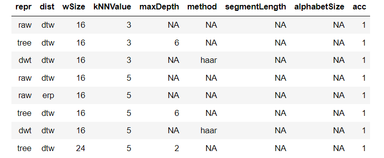

- As the competions continue, we also tried to generalize our model as follows: everyday we run two model sets. First one takes the best result according to its accuracy score within the table whereas the second one choses the closest three models to validation set in terms of accuracy and takes the mean of these three models. When we noticed that the second model gives better results as day goes by, we predicted our predictions mostly based on that.

### Results

- You can see our daily results of predictions below:

### WEEK 1

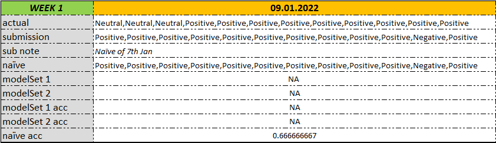

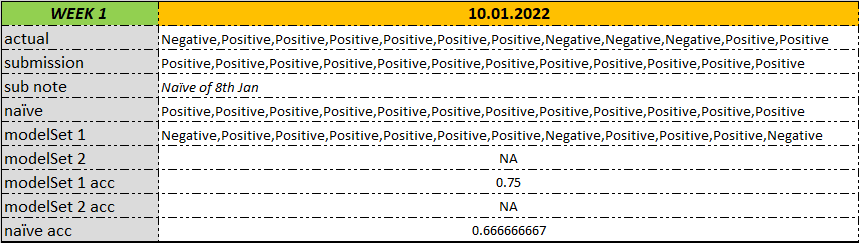

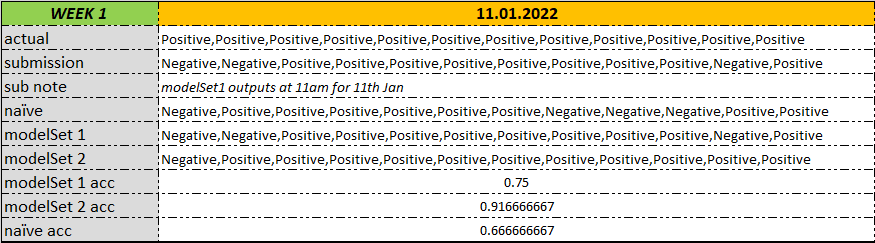

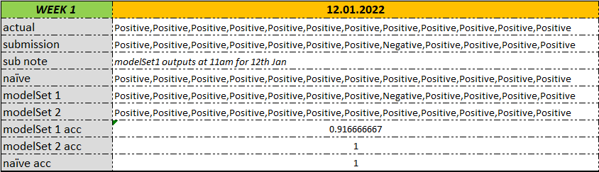

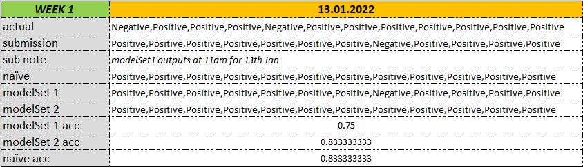

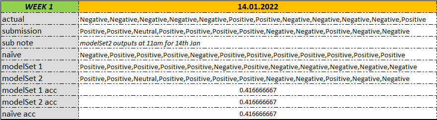

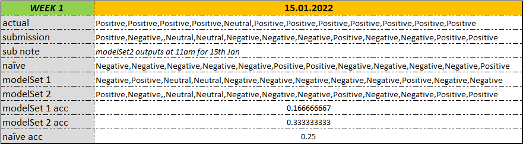

### WEEK 2

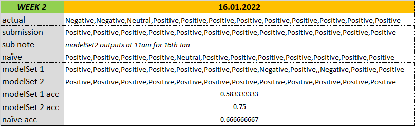

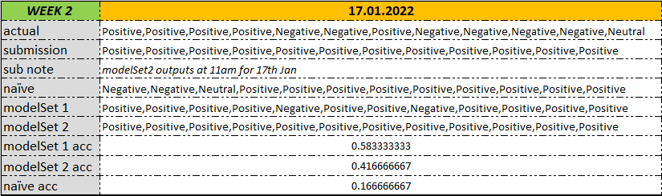

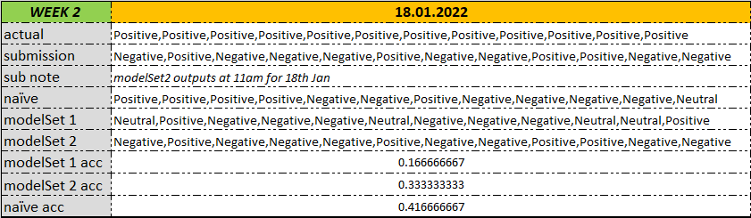

- Since our exams conflict, we could not submit our results from now on.

### Conclusion and Feature Work

- Even though our model scores gave good results at the beginning and the model we constructed is good, our model performance has lowered for the week 2. The main reason why it is low and can be considered as feature work is the datatables similarity. Our datatables for every hour is very similar since we have only data available before 5 a.m. and we cannot have a fixed buffer zone for every hour. Therefore we have a dynamic buffer zone which results in similar dataframes for every hour. A better approach could have been working with the one-day-before day data to have a fixed bufferzone.
- One other feature work could have been taking account of weather data. We took the mean of the seven locations' information to use in our model but we could not implement it. Thus, it might have improved our results if we did use.
- Lastly, we chose to predict the sign of the imbalance sign but we could have forecasted the net imbalance and then deciden on the sign but we did not prefer that way since we have already implemented a similar approach in midterm exam. We decided to continue our current appraoch.

### Code

https://bu-ie-48b.github.io/fall21-hserdary/files/project.ipynb